# Projeto do Módulo II - Intro to Data Science I

### Eduardo Passeto

**Histórico pessoal**  
Na minha infância, aparelhos de televisão coloridos eram uma raridade. Nós tínhamos um belo (e pesado) philco *P&B*.  
E uma das imagens que mais me marcou, em uma madrugada quente no Rio de Janeiro, foi a imagem daquele imenso navio, em tons cinzentos a desaparecer em um mar gelado. Titanic era o navio. O mesmo nome da "Fúria dos Titãs", um outro filme, desta vez britânico e dirigido por Desmond Davis, que me marcou a infância. A descrição deste filme pode ser vista aqui).  
Mais tarde fui saber que havia visto trechos do filme americano de 1953, dirigido por Jean Negulesco. Os dois filmes possuíam algo em comum: as vidas das pessoas eram deformadas por um trágico acidente de dimensões colossais. Dignos da ação dos deuses do Olimpo. Uma terrível tragédia da qual eu não gostaria de participar. O resumo deste filmes se encontra aqui).  
Mas a vida tem as suas surpresas e muitos anos depois me vi preso no sonho de participar, como tripulante, de estripulias. Desta vez no céu. Meu Titanic seria um avião.  
O sonho acabou não se realizando, embora tenha me formado em Engenharia e tenha tirado uma das melhores notas no quesito *navegação*, nas aulas de Topografia, já na Universidade.  
Em 1997, foi a vez de Cames Cameron dar a sua versão sobre o desastre que assolou o mundo, às portas da I Guerra Mundial. Pessoalmente, não gostei da nova versão do filme. E minha vida se afastou dos céus ou dos mares, quando fui me embrenhar pelos caminhos do serviço público. O filme mais novo baseado na tragédia do Titanic tem sua sinopse aqui).  
Confesso que ainda me pego, nas madrugadas frias da Capital Federal, no meu antigo sonho. E me questiono sobre o destino de tripulantes, no caso de acidentes com naves, ou aeronaves. Passageiros, nos tempos atuais recebem, quando vão fazer uma viagem de navio ou avião, um treinamento básico de emergência. Creio que na época esta instrução não era aplicada. E tripulantes recebem instruções avançadas a este respeito. No entanto, se a missão dos tripulantes é antes de tudo, a de salvar vidas de passageiros, é necessário que eles embarquem também nos botes de salva vidas.  
Crianças e mulheres são prioridade no caso de naufrágio.

E no caso do acidente do **Titanic**? O que o destino reservou para os passageiros e para os tripulantes daquele navio?  
São questões relativas a este tema que gostaria de desenvolver.

### Etapa de importação e análise dos dados

```python
# Primeiro vamos abrir o .csv e verificar seu conteúdo
import pandas as pd
#os pacotes que não for usar, vou deixar comentados!
import numpy as np
#import matplotlib as mlb
import matplotlib.pyplot as plt
#posso tentar fazer um pouco melhor...
#import seaborn as sns
#sns.set_style('darkgrid')

#eu quero rótulos em português e que eu entenda melhor...
rotulos = ['id_passageiro', 'sobreviveu', 'classe', 'nome', 'sexo', 'idade', 'parente', 'cresta', 'passagem',\
           'custo','cabine','embarcou']

#lendo o csv a partir do meu diretório de programas
#joguei fora a primeira linha de dados, que eram os nomes originais dos campos
#já que eu tenho um campo id_passageiro inteiro e sem repetições, ele será o índice da minha tabela de dados
df_titan = pd.read_csv('C:/pyprog/titanic-data-6.csv', skiprows=[0], names=rotulos, index_col="id_passageiro")
df_titan.head(20)
#df_titan.tail(5) #confere os últimos 5 registros - quero saber se o banco não vai se tornando discrepante para o final!
```

| id_passageiro | sobreviveu | classe | nome | sexo | idade | parente | cresta | passagem | custo | cabine | embarcou |
| --- | --- | --- | --- | --- | --- | --- | --- | --- | --- | --- | --- |
| 1 | 0 | 3 | Braund, Mr. Owen Harris | male | 22.0 | 1 | 0 | A/5 21171 | 7.2500 | NaN | S |
| 2 | 1 | 1 | Cumings, Mrs. John Bradley (Florence Briggs Th... | female | 38.0 | 1 | 0 | PC 17599 | 71.2833 | C85 | C |
| 3 | 1 | 3 | Heikkinen, Miss. Laina | female | 26.0 | 0 | 0 | STON/O2. 3101282 | 7.9250 | NaN | S |
| 4 | 1 | 1 | Futrelle, Mrs. Jacques Heath (Lily May Peel) | female | 35.0 | 1 | 0 | 113803 | 53.1000 | C123 | S |
| 5 | 0 | 3 | Allen, Mr. William Henry | male | 35.0 | 0 | 0 | 373450 | 8.0500 | NaN | S |
| 6 | 0 | 3 | Moran, Mr. James | male | NaN | 0 | 0 | 330877 | 8.4583 | NaN | Q |
| 7 | 0 | 1 | McCarthy, Mr. Timothy J | male | 54.0 | 0 | 0 | 17463 | 51.8625 | E46 | S |
| 8 | 0 | 3 | Palsson, Master. Gosta Leonard | male | 2.0 | 3 | 1 | 349909 | 21.0750 | NaN | S |
| 9 | 1 | 3 | Johnson, Mrs. Oscar W (Elisabeth Vilhelmina Berg) | female | 27.0 | 0 | 2 | 347742 | 11.1333 | NaN | S |
| 10 | 1 | 2 | Nasser, Mrs. Nicholas (Adele Achem) | female | 14.0 | 1 | 0 | 237736 | 30.0708 | NaN | C |
| 11 | 1 | 3 | Sandstrom, Miss. Marguerite Rut | female | 4.0 | 1 | 1 | PP 9549 | 16.7000 | G6 | S |
| 12 | 1 | 1 | Bonnell, Miss. Elizabeth | female | 58.0 | 0 | 0 | 113783 | 26.5500 | C103 | S |
| 13 | 0 | 3 | Saundercock, Mr. William Henry | male | 20.0 | 0 | 0 | A/5. 2151 | 8.0500 | NaN | S |
| 14 | 0 | 3 | Andersson, Mr. Anders Johan | male | 39.0 | 1 | 5 | 347082 | 31.2750 | NaN | S |
| 15 | 0 | 3 | Vestrom, Miss. Hulda Amanda Adolfina | female | 14.0 | 0 | 0 | 350406 | 7.8542 | NaN | S |
| 16 | 1 | 2 | Hewlett, Mrs. (Mary D Kingcome) | female | 55.0 | 0 | 0 | 248706 | 16.0000 | NaN | S |
| 17 | 0 | 3 | Rice, Master. Eugene | male | 2.0 | 4 | 1 | 382652 | 29.1250 | NaN | Q |
| 18 | 1 | 2 | Williams, Mr. Charles Eugene | male | NaN | 0 | 0 | 244373 | 13.0000 | NaN | S |
| 19 | 0 | 3 | Vander Planke, Mrs. Julius (Emelia Maria Vande... | female | 31.0 | 1 | 0 | 345763 | 18.0000 | NaN | S |
| 20 | 1 | 3 | Masselmani, Mrs. Fatima | female | NaN | 0 | 0 | 2649 | 7.2250 | NaN | C |

Observando os dados, há várias coisas que quero **melhorar**:

**Obs:** não dá para tratar todos os assuntos que eu gostaria, ou não finalizo o projeto!

Tenho que manter meu foco em resolver **alguns** problemas, e não **todos!**

```python
 print(df_titan.dtypes)
```

```
sobreviveu      int64
classe          int64
nome           object
sexo           object
idade         float64
parente         int64
cresta          int64
passagem       object
custo         float64
cabine         object
embarcou       object
dtype: object
```

Alguns **objetos** apresentam tipos não muito adequados:

1. *idade* não precisa ser um número de ponto flutuante - um inteiro é melhor para esse caso;
2. há diversos campos que aparecem como *object* e que necessitam de investigação especial.

Investigarei esses tipos a seguir...

```python
#embora o tipo de dados da coluna 'sexo' apareça como 'object', eu quero saber sua verdadeira natureza
#como meu banco de dados é indexado pelo id do passageiro, que começa com 1
#eu tenho que chamar pelo primeiro dado da lista
print(type(df_titan['sexo'][1]))
#outros...
print(type(df_titan['nome'][1]))
print(type(df_titan['passagem'][1]))
print(type(df_titan['cabine'][1]))
print(type(df_titan['embarcou'][1]))
```

```
<class 'str'>
<class 'str'>
<class 'str'>
<class 'float'>
<class 'str'>
```

Confirmou serem realmente **strings** de texto, muito bom!

```python
#no caso de "cabine", apareceu como float... (para mim, alguns dados apenas foram gravados como float!)
print("cabine 2 :",type(df_titan['cabine'][2]))
```

```
cabine 2 : <class 'str'>
```

Sim, já no segundo registro encontrei um **string** de texto... OK!

Eu poderia trabalhar o "sobreviveu com uma expressão **Lambda**", algo do tipo:

```
df.apply(lambda x: x.replace('0', 'não sobreviveu'))
```

No entanto, o *0 e 1* é bastante prático e intuitivo para minhas **filtragens**... tenho que pensar sobre isso

```python
df_titan.info()
```

```
<class 'pandas.core.frame.DataFrame'>
Int64Index: 891 entries, 1 to 891
Data columns (total 11 columns):
sobreviveu    891 non-null int64
classe        891 non-null int64
nome          891 non-null object
sexo          891 non-null object
idade         714 non-null float64
parente       891 non-null int64
cresta        891 non-null int64
passagem      891 non-null object
custo         891 non-null float64
cabine        204 non-null object
embarcou      889 non-null object
dtypes: float64(2), int64(4), object(5)
memory usage: 123.5+ KB
```

Agora eu sei também que há entradas **em branco** em algumas colunas.

Colunas que eu preciso realmente ter cuidado:

- **idade**
- **cabine**
- **embarcou**

E quero saber quantos **tipos** diferentes desse negócio das letras de *embarcou* existem no campo

```python
#print(df_titan.embarcou.groupby(df_titan['embarcou'])) #isso não funcionou!
#print(df_titan.groupby("embarcou")) #isso não funciona!

# número de valores únicos para qualidade em um conjunto de dados (pego "emprestado" do exercicio dos vinhos)
print("Valores únicos para embarcou: {0}".format(df_titan['embarcou'].nunique()))

print("Tipos no embarcou :", df_titan['embarcou'].unique()) #agora sim, peguei emprestado no carros... nan são vazios
```

```
Valores únicos para embarcou: 3
Tipos no embarcou : ['S' 'C' 'Q' nan]
```

**Observação:** parece que nos dados originais, isso era um número **composto**, tipo *S1*, ou *C2*...

Se voltar a trabalhar com esses dados em algum outro projeto, aprofundarei isso

Tenho um problema com idade... ela está como **float** e eu desejo idade em **inteiro**.

Mais um problema, ao tentar fazer uma transformação direta, o Pandas dá erro... eu tenho muito dado nulo **nan**

Então eu poderia criar uma função que se o dado fosse **nan**, ele me devolvesse um tipo de *valor*?

E se o que eu criasse fosse um *float*, que simplesmente convertesse para o *inteiro*...

Tantas possibilidades...

Para converter idade de **float** para **inteiro**, eu encontrei isso:

```
df_titan['idade'] = df_titan['idade'].apply(lambda x: int(x) if x == x else "")
```

Obviamente um código simples **não funciona**, por causa dos valores *nulos* preenchidos como *nan*:

```
a = 3.
a = nan
print (a)
b = int(a)
print (b)
```

Então eu preciso iterar dado por dado, verificar se é *nan* e eliminá-lo com uma indicação especial (idade=1000)

Primeiro eu pensei em usar (idade=0) para *nan*, mas não quero confundir com bebês!

- para inferência **estatística**, eu não posso simplesmente jogar linhas fora. Isso alteraria o valor da amostra
- mas eu poderia por exemplo, **agrupar** em menores de 18 anos, maiores de 18 e menores de 25... e assim por diante...
- assim eu teria um **perfil etário** compreensível para o tipo de dado que eu colhesse
- e aqueles sem idade, poderia indicar de alguma maneira que há dados **corrompidos** no meu banco!

Uma outra coisa legal que eu poderia fazer é saber se mais mulheres, ou mais homens **sobreviveram** ao desastre

### Etapa de limpeza dos dados

```python
#como vou limpar o banco, melhor eu tirar uma cópia ele antes...
df_sexo = df_titan.copy()

#eliminar colunas desnecessárias...
df_sexo.drop(['cresta', 'passagem','cabine', 'custo', 'embarcou', 'classe'], axis=1, inplace=True)
#não quero jogar fora campos demais: quero um perfil do passageiro!

#e dar uma olhada como ficou
df_sexo.head(20)
```

[output not shown]

```python
#quero descartar dados com sexo em branco
df_sexo.dropna(subset = ['idade'], inplace = True)
print(df_sexo.info())
```

```
<class 'pandas.core.frame.DataFrame'>
Int64Index: 714 entries, 1 to 891
Data columns (total 5 columns):
sobreviveu    714 non-null int64
nome          714 non-null object
sexo          714 non-null object
idade         714 non-null float64
parente       714 non-null int64
dtypes: float64(1), int64(2), object(2)
memory usage: 33.5+ KB
None
```

Pronto, **eliminei** os brancos em sexo (e em idade!)

```python
df_sexo.idade = df_sexo.idade.astype(int)
df_sexo.head(20) #eu quero deixar a apresentação de "idade" legal
```

| id_passageiro | sobreviveu | nome | sexo | idade | parente |
| --- | --- | --- | --- | --- | --- |
| 1 | 0 | Braund, Mr. Owen Harris | male | 22 | 1 |
| 2 | 1 | Cumings, Mrs. John Bradley (Florence Briggs Th... | female | 38 | 1 |
| 3 | 1 | Heikkinen, Miss. Laina | female | 26 | 0 |
| 4 | 1 | Futrelle, Mrs. Jacques Heath (Lily May Peel) | female | 35 | 1 |
| 5 | 0 | Allen, Mr. William Henry | male | 35 | 0 |
| 7 | 0 | McCarthy, Mr. Timothy J | male | 54 | 0 |
| 8 | 0 | Palsson, Master. Gosta Leonard | male | 2 | 3 |
| 9 | 1 | Johnson, Mrs. Oscar W (Elisabeth Vilhelmina Berg) | female | 27 | 0 |
| 10 | 1 | Nasser, Mrs. Nicholas (Adele Achem) | female | 14 | 1 |
| 11 | 1 | Sandstrom, Miss. Marguerite Rut | female | 4 | 1 |
| 12 | 1 | Bonnell, Miss. Elizabeth | female | 58 | 0 |
| 13 | 0 | Saundercock, Mr. William Henry | male | 20 | 0 |
| 14 | 0 | Andersson, Mr. Anders Johan | male | 39 | 1 |
| 15 | 0 | Vestrom, Miss. Hulda Amanda Adolfina | female | 14 | 0 |
| 16 | 1 | Hewlett, Mrs. (Mary D Kingcome) | female | 55 | 0 |
| 17 | 0 | Rice, Master. Eugene | male | 2 | 4 |
| 19 | 0 | Vander Planke, Mrs. Julius (Emelia Maria Vande... | female | 31 | 1 |
| 21 | 0 | Fynney, Mr. Joseph J | male | 35 | 0 |
| 22 | 1 | Beesley, Mr. Lawrence | male | 34 | 0 |
| 23 | 1 | McGowan, Miss. Anna "Annie" | female | 15 | 0 |

### Etapa de análises e desenvolvimento

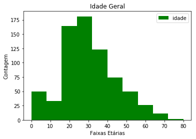

```python
df_sexo['idade'].plot(kind="hist", title="Idade Geral", color = "green", legend = True);
plt.xlabel('Faixas Etárias')
plt.ylabel('Contagem');
```

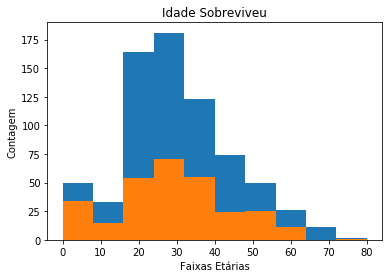

```python
df_sexo['idade'].plot(kind="hist", title="Idade Geral");
df_sobreviveu = df_sexo.query('sobreviveu == 1')
df_sobreviveu['idade'].plot(kind="hist", title="Idade Sobreviveu");
plt.xlabel('Faixas Etárias')
plt.ylabel('Contagem');
```

Coloquei de fundo o diagrama geral, para ter ideia da **forma**

Pronto! numa comparação visual, posso verificar que o diagrama de **sobrevivência** apresenta duas distorções em relação ao diagrama geral de idades:  
1) à esquerda, percebe-se que as crianças tiveram uma chance relativamente mais alta de sobreviver;  
2) à direita, percebe-se ao contrário, que os velhos praticamente desaparecem do diagrama de sobrevivência (há alguns casos peculiares de alta idade que poderiam ser investigados!)

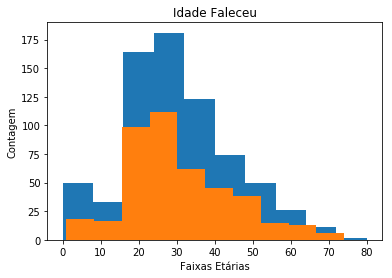

```python
df_sexo['idade'].plot(kind="hist", title="Idade Geral");
df_faleceu = df_sexo.query('sobreviveu == 0')
df_faleceu['idade'].plot(kind="hist", title="Idade Faleceu");
plt.xlabel('Faixas Etárias')
plt.ylabel('Contagem');
```

Eu gostaria de ter visto aqui que **crianças** estivessem ausentes no diagrama de falecimento!

Por **último** neste tema, eu quero verificar a correlação entre o campo *idade* e *parente*.

Quero testar para ver se existe alguma correlação possível.

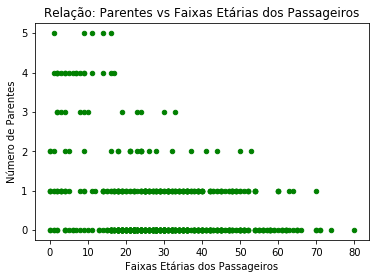

```python
df_sexo.plot(kind='scatter', x='idade', y='parente', title='Relação: Parentes vs Faixas Etárias dos Passageiros', color = 'green');
plt.xlabel('Faixas Etárias dos Passageiros')
plt.ylabel('Número de Parentes');
```

## Uma Relação Curiosa

Observe: existe uma dispersão **menor** de idades de passageiros para a **esquerda**, conforme o número de parentes **aumenta**.

Ou seja, existe uma **tendência** de que o número de parentes embarcados seja **maior**, quando o passageiro é mais **novo**.

Isso parece intuitivo, pois na época, as famílias constituídas costumavam possuir um casal e muitos filhos. E que crianças normalmente não viajavam **desacompanhadas** em navios *(não existiam aviões na época e o translado durava mais de um mês entre o velho e o novo mundo)*.

Espere um minuto! Eu confiei **demais** na série de dados que eu recebi!

Eu quero conferir se realmente não trabalhei com valores **repetidos**!

```python
#função para verificar se possui valores duplicados (isso foi reaproveitado das classes e pode ser bem útil)
def tem_duplicados(df):
    if df.duplicated().any():
        print("Possui {0} valores duplicados".format(df.duplicated().sum()))
    else:
        print("Não possui valores duplicados")
tem_duplicados(df_titan) #eu entro o nome do meu datafile aqui na chamada da função!
```

```
Não possui valores duplicados
```

Ufa! Não tive problemas de **duplicações**!

Nem sempre devemos confiar demais no que recebemos...

*(e de qualquer maneira, agora a função está adaptada para este projeto)*

*(devidamente furtada dos exemplos de classe do Módulo I do Curso)*

Mais uma função útil para ser **roubartilhada** em projetos é uma complementação desta...

```python
#função que elimina dados duplicados
def des_duplicados(df):
    df.drop_duplicates(inplace=True)
#des_duplicados(df_titan) #mesma coisa da anterior!
```

**Lembrete:** o fato de haver dados iguais **NEM SEMPRE** significa que eles sejam **REALMENTE** duplicados!

Maravilha, os dados agora estão bastante concisos e nenhuma **duplicação** foi encontrada.

```python
print ("Forma da tabela: {} linhas e {} colunas".format(df_titan.shape[0], df_titan.shape[1]))
```

```
Forma da tabela: 891 linhas e 11 colunas
```

Agora sim, ficou elegante a saída dos dados (isso estava horrível)

## Pequeno Relatório de Aquisição e Análise dos Dados

Isso não é a fase final, apenas um relato intermediário!  
*Até o momento...*  
não encontrei dados duplicados e foi possível fazer uma migração razoável do csv. Na minha primeira tabela, tenho 891 registros, distribuídos em 11 colunas. Nem todas as colunas eu tenho boa compreensão. Ainda ando pesquisando este arquivo [aqui](https://www.kaggle.com/c/titanic). Mas há documentações mais extensas [aqui](http://web.stanford.edu/class/archive/cs/cs109/cs109.1166/problem12.html).  
Como *"alguns combatem [incêndios](http://snicket.wikia.com/wiki/V.F.D.), enquanto outros produzem incêndios"*, encontrei bastante código útil [aqui](https://www.kaggle.com/inturiyam/exploring-titanic-data-using-pandas-dataframes). Como o objetivo de um curso é aprender e não copiar código de terceiros, vou tentar fazer do meu jeito. Às vezes é bom reaproveitar códigos de outras pessoas, pois ficamos viciados nas formas mais *brutas* de programação. Tive dificuldade especial com função **Lambda**, então certamente criarei alguma rotina que precise usar esta tecnologia. Não se faz ginástica para fortalecer músculos que já são fortes... e é claro (para não ser óbvio) *"mula morta não pode morrer..."*

Eu quero fazer uma análise mais detalhada das **faixas etárias** dos sobreviventes.

Para isso vou começar tirando uma **cópia** da minha tabela

```python
df_idade = df_titan.copy()
#eu sei que tenho alguns dados em branco nessa coluna e irei eliminar essas linhas...
#descarte algumas colunas inúteis deste conjunto (pode reacrescentar, se achar necessário)
df_idade.drop(['parente', 'cresta', 'passagem','cabine'], axis=1, inplace=True)
#agora descarte linhas com idade em branco
#DataFrame.dropna(axis=0, how='any', thresh=None, subset=None, inplace=False)[source]
df_idade.dropna(subset = ['idade'], inplace = True)
print(df_idade.info()) #eu preciso obter 714 registros com ID, então correu tudo bem!
#print(df_titan.info()) #apenas para me certificar de que não estraguei o conjunto de dados original
```

```
<class 'pandas.core.frame.DataFrame'>
Int64Index: 714 entries, 1 to 891
Data columns (total 7 columns):
sobreviveu    714 non-null int64
classe        714 non-null int64
nome          714 non-null object
sexo          714 non-null object
idade         714 non-null float64
custo         714 non-null float64
embarcou      712 non-null object
dtypes: float64(2), int64(2), object(3)
memory usage: 44.6+ KB
None
```

```python
df_idade.idade = df_idade.idade.astype(int)
df_idade.head(20)
```

| id_passageiro | sobreviveu | classe | nome | sexo | idade | custo | embarcou |
| --- | --- | --- | --- | --- | --- | --- | --- |
| 1 | 0 | 3 | Braund, Mr. Owen Harris | male | 22 | 7.2500 | S |
| 2 | 1 | 1 | Cumings, Mrs. John Bradley (Florence Briggs Th... | female | 38 | 71.2833 | C |
| 3 | 1 | 3 | Heikkinen, Miss. Laina | female | 26 | 7.9250 | S |
| 4 | 1 | 1 | Futrelle, Mrs. Jacques Heath (Lily May Peel) | female | 35 | 53.1000 | S |
| 5 | 0 | 3 | Allen, Mr. William Henry | male | 35 | 8.0500 | S |
| 7 | 0 | 1 | McCarthy, Mr. Timothy J | male | 54 | 51.8625 | S |
| 8 | 0 | 3 | Palsson, Master. Gosta Leonard | male | 2 | 21.0750 | S |
| 9 | 1 | 3 | Johnson, Mrs. Oscar W (Elisabeth Vilhelmina Berg) | female | 27 | 11.1333 | S |
| 10 | 1 | 2 | Nasser, Mrs. Nicholas (Adele Achem) | female | 14 | 30.0708 | C |
| 11 | 1 | 3 | Sandstrom, Miss. Marguerite Rut | female | 4 | 16.7000 | S |
| 12 | 1 | 1 | Bonnell, Miss. Elizabeth | female | 58 | 26.5500 | S |
| 13 | 0 | 3 | Saundercock, Mr. William Henry | male | 20 | 8.0500 | S |
| 14 | 0 | 3 | Andersson, Mr. Anders Johan | male | 39 | 31.2750 | S |
| 15 | 0 | 3 | Vestrom, Miss. Hulda Amanda Adolfina | female | 14 | 7.8542 | S |
| 16 | 1 | 2 | Hewlett, Mrs. (Mary D Kingcome) | female | 55 | 16.0000 | S |
| 17 | 0 | 3 | Rice, Master. Eugene | male | 2 | 29.1250 | Q |
| 19 | 0 | 3 | Vander Planke, Mrs. Julius (Emelia Maria Vande... | female | 31 | 18.0000 | S |
| 21 | 0 | 2 | Fynney, Mr. Joseph J | male | 35 | 26.0000 | S |
| 22 | 1 | 2 | Beesley, Mr. Lawrence | male | 34 | 13.0000 | S |
| 23 | 1 | 3 | McGowan, Miss. Anna "Annie" | female | 15 | 8.0292 | Q |

A visualização mostra progresso nos **campos** alterados

```python
#print(len(df_idade))
#será que a menoridade em 1912 era aos 18?
#Se fosse, será que menores de idade tiveram maior chance de sobreviver?
df_menores = df_idade.query('idade < 18')
df_menoresSob = df_menores.query('sobreviveu == 1')
df_menoresFal = df_menores.query('sobreviveu == 0')
#print(len(df_menores))
#print(len(df_menores) == len(df_menoresSob) + len(df_menoresFal)) #só para saber se a soma confere

#será que 60 anos em 1912 era uma boa idade para ser considerado um idoso?
#E idosos, será que tiveram menor chance de sobreviver?
df_idosos = df_idade.query('idade >= 60') #fez 60, já conta
df_idososSob = df_idosos.query('sobreviveu == 1')
df_idososFal = df_idosos.query('sobreviveu == 0')
#print(len(df_idosos))
#print(len(df_idosos) == len(df_idososSob) + len(df_idososFal)) #só para saber se não deu problema aqui

#restantes
df_restantes = df_idade.query ('idade >= 18 and idade < 60')
#print (len(df_restantes))
#print(len(df_idade) == len(df_menores) + len(df_idosos) + len(df_restantes)) #só para saber se não comi bola

print('De {} passageiros cujos dados de idade existiam, {} eram menores de 18 anos e {} tinham 60 ou mais anos de vida'.\
      format(len(df_idade), len(df_menores), len(df_idosos)))
print('Destes, {} menores sobreviveram e {} faleceram; e {} idosos sobreviveram e {} faleceram'.format(len(df_menoresSob),\
      len(df_menoresFal), len(df_idososSob), len(df_idososFal)))
```

```
De 714 passageiros cujos dados de idade existiam, 113 eram menores de 18 anos e 26 tinham 60 ou mais anos de vida
Destes, 61 menores sobreviveram e 52 faleceram; e 7 idosos sobreviveram e 19 faleceram
```

Relatórios escritos não são muito intuitivos...

E se fizéssemos isso na forma de **gráficos**?

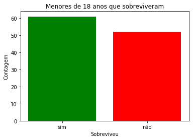

```python
#podemos traçar gráficos de barras com rótulos adequados...
sobreviveu = [1, 2]
a = len(df_menoresSob)
b = len(df_menoresFal)
heights = [a, b]
labels = ['sim', 'não']
plt.bar(sobreviveu, heights, tick_label=labels, color = ['green', 'red'])
plt.title('Menores de 18 anos que sobreviveram')
plt.xlabel('Sobreviveu')
plt.ylabel('Contagem');
```

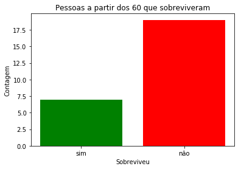

```python
#podemos traçar gráficos de barras com rótulos adequados...
sobreviveu = [1, 2]
a = len(df_idososSob)
b = len(df_idososFal)
heights = [a, b]
labels = ['sim', 'não']
plt.bar(sobreviveu, heights, tick_label=labels, color = ['green', 'red'])
plt.title('Pessoas a partir dos 60 que sobreviveram')
plt.xlabel('Sobreviveu')
plt.ylabel('Contagem');
```

**Comentário**  
É horrível trabalhar com inferências baseadas em dados reais. É tenebroso saber que entre *113* menores de idade, praticamente a *metade* deles perdeu a vida nesta tragédia.  
Este conjunto de dados é ruim de visualizar apenas em números. Vou tentar plotar um gráfico de tudo isso para ver como fica.

E da mesma maneira que [Hari Seldon](https://pt.wikipedia.org/wiki/Hari_Seldon) previu a queda do Império Galáctico em 500 anos, não querendo correr o risco de prever o fim do meu curso sem terminar este projeto, é melhor eu tocar em frente...

Depois de trabalhar com dados **trágicos**, algo que eu gostaria de fazer e considero desafiador.  
Para descontrair, eu quero saber quais os pronomes de tratamento existentes para as pessoas que embarcaram no Titanic.  
Mr., Mrs. seriam esperados... mas existiram outros? Logo nos primeiros eu pude notar um Master... E o que mais?  
E em qual número? *(se fosse nos tempos atuais, nem imagino a variedade de tipos que existiriam!)*

Se eu encontrasse alguma **imagem** útil para inserir, poderia fazer por este **comando**

```
from IPython.display import Image

Image(img/picture.png)

[title](img/picture.png)
```

```python
#para extrair o pronome de tratamento do nome...
a =df_titan['nome'].str.lower().str.extract('([a-z]*\.)', expand=True)

#eu acrescentei a coluna de tratamento, para poder lidar com esses dados...
df_titan['tratamento'] = a
#print(a)

#df_titan['tratamento'] #,'tratamento']
b = df_titan['tratamento'].value_counts() #groupby(['tratamento']) #.groupby(['tratamento']).agg(['tratamento'])
#print(b)

c = b.index.tolist() #meus tipos
#print(c)

d = b.to_frame() #enfim!
print(d)
```

```
           tratamento
mr.               517
miss.             182
mrs.              125
master.            40
dr.                 7
rev.                6
mlle.               2
major.              2
col.                2
ms.                 1
don.                1
countess.           1
lady.               1
sir.                1
mme.                1
jonkheer.           1
capt.               1
```

```python
#desativado
#print (d['tratamento'][0]) #apenas para saber como extrair um valor da lista de contagens
```

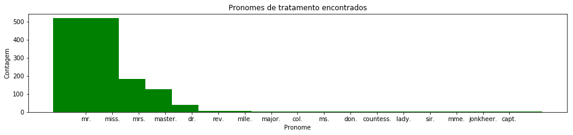

```python
#podemos traçar gráficos de barras com rótulos adequados...
largura = 2
cels = list(range(1,len(c)*largura,largura))
#print(cels)
#cels = [10,10,10,10,10,10,10,10,10,10,10,10,10,10,10,10,10]
#print(cels)
contagens = [517, 182, 125, 40, 7, 6, 2, 2, 2, 1, 1, 1, 1, 1, 1, 1, 1] #primeira tentativa, copiei valores um a um
contagens = [d['tratamento'][f] for f in range(0,len(d))] #consegui usar a compreensão de listas!
#print(contagens)
fig = plt.figure(figsize=(16,3))
labels = c #rótulos extraídos dos pronomes de tratamento encontrados
plt.bar(cels, contagens, 5, align='center', linewidth=2, tick_label=labels, color='green', label=True) #, figsize=(2,2)) #, rwidth=2) #, size=100, color = green) #, size = [10,3])
#plt.rcParams["figure.figsize"] = [16,9]
plt.title('Pronomes de tratamento encontrados')
plt.xlabel('Pronome')
plt.ylabel('Contagem');
```

**Observação:** o gráfico não ficou muito bonito, mas dá para ler todos os pronomes de tratamento, com quantidades somadas.

- Uma possível explicação é que aquela seria uma sociedade machista e dominada pelos "senhores", reconhecidos pelo prenome "mr."
- outra explicação possível é que aquela época foi uma era de forte migração do "velho mundo" para os Estados Unidos da América e portanto, o número de passageiros do sexo masculino e que gostava de ser tratado como "mr." era mais elevado do que o resto dos tratamentos possíveis...

Outra curiosidade, havia uma **condessa** a bordo! Agora, o que é uma **jonkheer**? Graças ao Google chegamos a uma explicação: é um título de nobreza específico dos países baixos!

### Etapa de conclusões e limitações

**Conclusões**  
Fizemos alguns avanços, além do aprendizado das ferramentas do próprio curso. E isso foi divertido. No caso do Titanic:

1. conseguimos limpar sujeiras e criar algumas variantes da tabela original, que além de nos fornecerem algumas informações interessantes, podem apresentar listagens mais nítidas sobre os dados em foco. Isso é legal;
2. percebems que aquela regra de *mulheres e crianças primeiro* nem sempre é obedecida. Não é exatamente um *cada um por todos*, uma vez que o acesso aos botes de salva vidas foi restrito e controlado pela tripulação do navio. Há membros da tripulação que portam armas em todos os navios (em aeronaves essa regra não é utilizada, por conta da fatalidade que a perfuração da fuselagem causaria) e normalmente a lei, ou a *ordem do capitão* é cumprida;
3. no nosso caso, observamos um elevado número de *crianças* mortas e um número curioso de *idosos* que foram salvos. Isso normalmente indica *distorções* no que aconteceu de fato naquele navio, no momento do acidente. Algumas vezes, estas distorções são inclusive *criminosas*;
4. além disso, pudemos observar, ao cruzar o número de parentes embarcados com idade do passageiro, uma curiosa tendência a, quando o número de parentes embarcados ser mais elevado, a idade do passageiro tender a ser reduzida. É claro que isso é intuitivo, pois *famílias grandes* tendem a ter *crianças*! Como não estávamos esperando inicialmente encontrar tal correlação, houve a surpresa. É legal explorar dados, algumas vezes somos surpreendidos por alguma *correlação* curiosa (e algumas dessas correlações deram origem por exemplo, à descoberta da [penicilina](https://pt.wikipedia.org/wiki/Penicilina)!

E, por falar em penicilina, gostaria de citar o trecho da Wikipédia na qual cita que: *"tem-se dito que muitas descobertas científicas são feitas ao acaso. O acaso, já dizia Pasteur, só favorece aos espíritos preparados e não prescinde da observação."*. Lindas palavras. E do meu ponto de vista, nada mais verdadeiro!

**Limitações**

1. em Estatística, normalmente se trabalha com *amostras*. A partir do tratamento dessas amostras e baseados na [lei dos grandes números](https://pt.wikipedia.org/wiki/Lei_dos_grandes_n%C3%BAmeros), nós podemos tirar conclusões baseados na *inferência estatística*;
2. ocorre que em nosso caso, não estamos trabalhando com *amostras* e sim com um conjunto *selecionado* e *não aleatório* de dados. Isso altera totalmente o resultado da análise e ela passa a não ser mais confiável para fins de *inferência*;
3. Embora tenhamos diversos gráficos apontando possíveis e curiosoas distorções nas contagens e dispersão de dados, devemos elmbrar que estes são resultados meramente *ilustrativos*, uma vez que violamos diversos princípios básicos da Estatística;
4. outra coisa que devemos perceber é que estaos trabalhando com, além de uma pequena amostra *não aleatória*, escolhida a fim de pegar os registros menos deteriorados do navio, com um número *limitado* de campos;
5. quando temos poucos campos em um determinado banco de dados, qualquer análise se torna *crítica*, uma vez que não temos como cruzar informações e verificar a *coerência interna* desses dados;
6. para piorar, o número de colunas foi realmente pequeno! Então foi necessário agir com muita criatividade para obter algum *suco* destes dados (ou seja, consultas que nos fornecessem *informação útil*, isso é mais ou menos como espremer uma laranja!);
7. e por fim, uma das melhores maneiras de se trabalhar com *consultas de bancos de dados* é cruzar informações de diversas fontes. Por exemplo, cruzar os dados do banco do Titanic com os dados do [Museu do Holocausto](http://www.yadvashem.org/). O Yad Vashem mantém um banco de dados genealógico de todas as famílias de hebreus. O cruzamento dos nomes dos passageiros poderia em alguns casos, nos trazer informações interessantes sobre possíveis laços de parentescos ocultos, motivo da viagem, entre outros. Este é apenas um exemplo. Mas de fato, não fizemos nenhum cruzamento de dados com fontes *externas*, o que é um grande erro!

## Observação Final sobre o Curso

É bastante exaustivo lidar com o **Jupyter Notebook** pela primeira vez. Isso aqui lembra aqueles antigos editores de texto, existentes para o **Apple II** ou para os primeiros **PC XT Turbo**, como **Totalworks**. Às vezes ele inexplicavelmente desconfigura.

Lidar com tabelas também não é nada fácil, nos acostumamos à sintaxe do **SQL Server** e do **Access.mdb**. Daí, parece se estar lidando novamente com o **Dbase IV**.

E o que dizer do **Python**? Ele lembra muito as linhas do Basic residente dos **Apple II**. Você simplesmente ligava a máquina, ela fazia um **beep** e você saía programando...

*Mas o que dizer do resultado de tudo isso?*

Apesar de lembrar tecnologia arcaica, o **Python** possui poder absoluto de processamento paralelo e com o comando **Yield**, capacidade absurda de usando uma linguagem interpretada, criar estruturas compiladas de objetos!

Com relação ao **Jupyter Notebook**, apesar de à primeira vista parecer a coisa mais tosca do mundo, o potencial científico é absolutamente demonstrado. Não é necessário configurar todo um ambiente de programação para se sair desenvolvendo código científico. Exportação para HTML é muito bem vinda e o formato, lembrando *"papers"* acadêmicos é excelente!

O que vou fazer com essa ferramenta? Começar a implantar, junto com meus colegas, uma incubadora de algoritmos para tratamento científico de dados hidrológicos, para uso no Sistema Nacional de Informações em Recursos Hídricos, Brasil. Acredito que em breve teremos notícias disso [aqui](http://www.snirh.gov.br/)!

Eduardo Passeto  
Especialista em Recursos Hídricos  
COCAD-Coordenação de Cadastro  
Agência Nacional de Águas  
epasseto@ana.gov.br